# BIOS 611 HW1 Data visualisation (Chapter 3)

   Answer:

   If I map a continuous variable, namely `displ` to `color`, R uses a range of colors for the markers on the plot according to the value of displ.

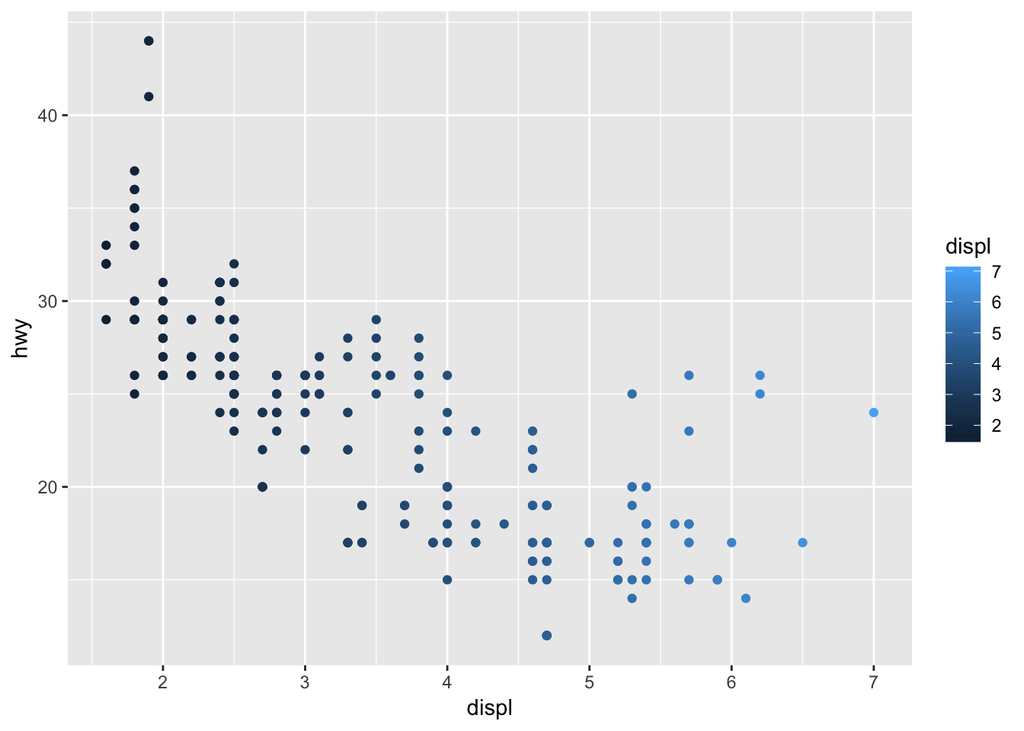

   ```r
   # Map a continuous variable to color
   library(ggplot2)
   ggplot(data = mpg) +
     geom_point(mapping = aes(x = displ, y = hwy, color = displ))
   ```

   If I map a continuous variable, namely `displ` to `size`, R uses a range of sizes for the markers on the plot according to the value of displ.

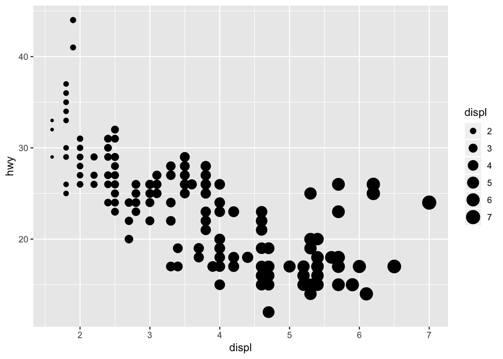

   ```r
   # Map a continuous variable to size
   library(ggplot2)
   ggplot(data = mpg) +
     geom_point(mapping = aes(x = displ, y = hwy, size = displ))
   ```

   On the other hand, if I map a continuous variable, namely `displ` to `shape`, R gives an error message because there are only 6 shapes available for R to choose from, so it cannot plot different shape markers according to a continuous variable.

   ```r
   # Map a continuous variable to shape
   library(ggplot2)
   ggplot(data = mpg) +
     geom_point(mapping = aes(x = displ, y = hwy, shape = displ))
   # This produces an error message!
   ```

   Categorical variables typically work much better for mapping to `color`, `size`, and `shape` because there is a finite number of different values of the variable. Particularly, the difference here is that you can use map a categorical variable to `shape`. See below:

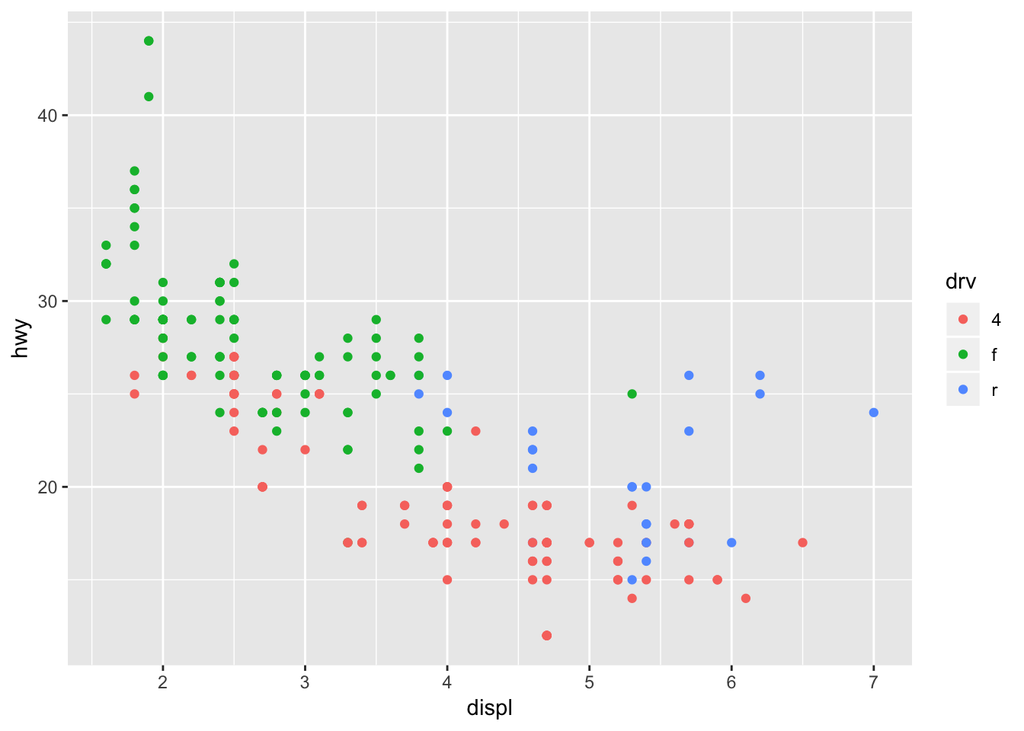

   ```r
   # Map a categorical variable to color
   library(ggplot2)
   ggplot(data = mpg) +
     geom_point(mapping = aes(x = displ, y = hwy, color = drv))
   ```

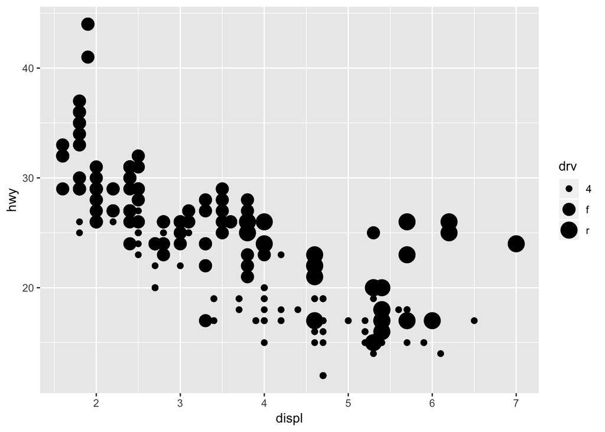

   ```r
   # Map a categorical variable to size
   library(ggplot2)
   ggplot(data = mpg) +
     geom_point(mapping = aes(x = displ, y = hwy, size = drv))
   ```

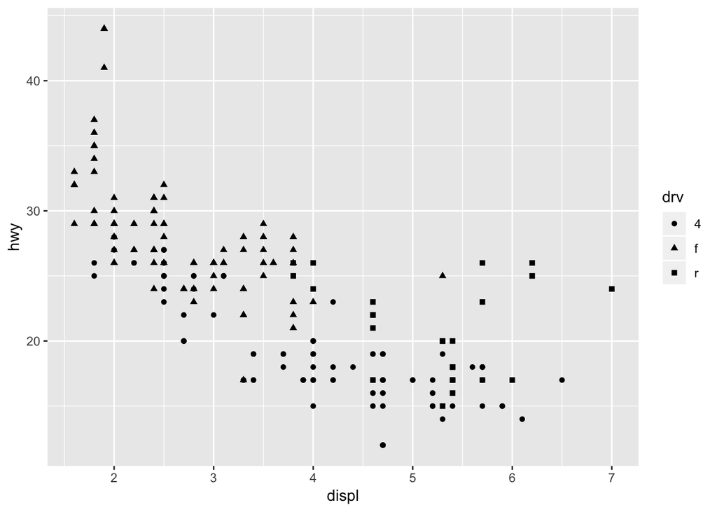

   ```r
   # Map a categorical variable to size
   library(ggplot2)
   ggplot(data = mpg) +
     geom_point(mapping = aes(x = displ, y = hwy, shape = drv))
   ```

4. What happens if you map the same variable to multiple aesthetics?

   Answer: Here I mapped the x variable, `displ`, to `color` and `size`, and R produces 2 different legends showing the makers varying by color and size according to the value of `disp`.

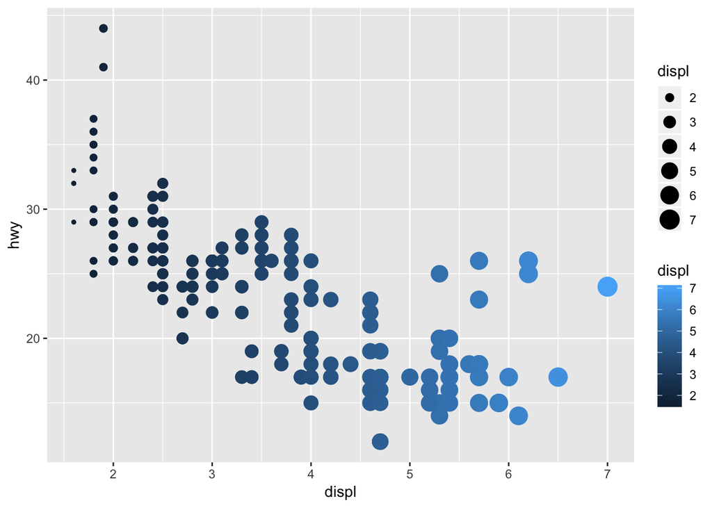

   ```r
   library(ggplot2)
   ggplot(data = mpg) +
     geom_point(mapping = aes(x = displ, y = hwy, color = displ, size = displ))
   ```

5. What does the `stroke` aesthetic do? What shapes does it work with? (Hint: use `?geom_point`)